# **Ejercicios 1 - Estadistica Computacional (13311)**

## **DESAFIO 3**

### *“Construya una función que permita a un jugador jugar al piedra papel o tijeras.”*

Considerando que estamos utilizando R Markdown, la entrada será colocada en bruto, pero se señalará con un comentario cual es para que se pueda cambiar si asi se desea.

```r
entrada = "tijeras" # CAMBIE ESTA VARIABLE SI DESEA PROBAR OTRA ENTRADA

# Entrada: Un string correspondiente a "piedra", "papel" o "tijeras"
# Salida: Un string diciendo si se gano, perdio o empato la partida
# Descripcion: Un simple juego de piedra, papel o tijeras contra la computadora.
piedra_papel_tijeras = function(entrada){
  opciones_validas = c("piedra", "papel", "tijeras")
  if(entrada %in% opciones_validas){
    opcion = sample(1:3,1)
    enemigo = opciones_validas[opcion]
    if(enemigo == "piedra"){
      if(entrada == "piedra"){
        print("Usted eligio: piedra")
        print("La computadora eligio: piedra")
        return("Resultado: Empate!")
      }
      if(entrada == "papel"){
        print("Usted eligio: papel")
        print("La computadora eligio: piedra")
        return("Resultado: Usted gana la partida!")
      }
      if(entrada == "tijeras"){
        print("Usted eligio: tijeras")
        print("La computadora eligio: piedra")
        return("Resultado: Usted pierde la partida!")
      }
    }
    if(enemigo == "papel"){
      if(entrada == "piedra"){
        print("Usted eligio: piedra")
        print("La computadora eligio: papel")
        return("Resultado: Usted pierde la partida!")
      }
      if(entrada == "papel"){
        print("Usted eligio: papel")
        print("La computadora eligio: papel")
        return("Resultado: Empate!")
      }
      if(entrada == "tijeras"){
        print("Usted eligio: tijeras")
        print("La computadora eligio: papel")
        return("Resultado: Usted gana la partida!")
      }
    }
    if(enemigo == "tijeras"){
      if(entrada == "piedra"){
        print("Usted eligio: piedra")
        print("La computadora eligio: tijeras")
        return("Resultado: Usted gana la partida!")
      }
      if(entrada == "papel"){
        print("Usted eligio: papel")
        print("La computadora eligio: tijeras")
        return("Resultado: Usted pierde la partida!")
      }
      if(entrada == "tijeras"){
        print("Usted eligio: tijeras")
        print("La computadora eligio: tijeras")
        return("Resultado: Empate!")
      }
    }
  }
  else{
    return("Opcion invalida, intentelo nuevamente.")
  }
}
# LLamado a la función
piedra_papel_tijeras(entrada)
```

```
## [1] "Usted eligio: tijeras"
## [1] "La computadora eligio: tijeras"
```

```
## [1] "Resultado: Empate!"
```

## **DESAFIO 4**

### *1.- Seleccione un conjunto de datos desde el paquete ‘datasets’ de R. Para ver los datasets disponibles en la consola puede utilizar la función “data()” o puede consultarlos en la página web https://stat.ethz.ch/R-manual/R-devel/library/datasets/html/00Index.html. Una vez seleccionado puede utilizar la función data(‘nombre_del_dataset’) para cargar el dataset.*

Cargando los datos con data(), vamos a elegir el dataset “UCBAdmissions”. Vamos a utilizar force() para poder ver el contenido del dataset.

```r
data("UCBAdmissions")
force(UCBAdmissions)
```

```
## , , Dept = A
##
##           Gender
## Admit      Male Female
##   Admitted  512     89
##   Rejected  313     19
##
## , , Dept = B
##
##           Gender
## Admit      Male Female
##   Admitted  353     17
##   Rejected  207      8
##
## , , Dept = C
##
##           Gender
## Admit      Male Female
##   Admitted  120    202
##   Rejected  205    391
##
## , , Dept = D
##
##           Gender
## Admit      Male Female
##   Admitted  138    131
##   Rejected  279    244
##
## , , Dept = E
##
##           Gender
## Admit      Male Female
##   Admitted   53     94
##   Rejected  138    299
##
## , , Dept = F
##
##           Gender
## Admit      Male Female
##   Admitted   22     24
##   Rejected  351    317
```

### *2.- Describa el conjunto de datos y explique para que fue o podría ser utilizado. Puede usar la función help(‘nombre_del_dataset’). ¿Cuál es la fuente de los datos?*

El conjunto de datos trata sobre los postulantes a UC Berkeley, donde se da a conocer información sobre los postulantes para los seis grandes departamentos de Berkeley y cuya información proviene del año 1973. Contiene tres variables, la primera informa de si una persona fue aceptada o no, la segunda dice su genero y la tercera dice al departamento al que fue aceptado.

Si utilizamos la funcion help(“UCBAdmissions”) podemos encontrar mas información sobre el data set, donde también se da a conocer el detalle de que el dataset se utiliza frecuentemente para ilustrar la parajona de Simpson, el cual es un fenomeno en probablidad y estadistica que ilustra una asociación entre dos variables en una población que surge, desaparece o se invierte cuando la población se divide en subpoblaciones.

### *3.- Describa cada variable, indique a qué tipo de variable corresponde, indique qué valores puede tomar y su unidad de medida.*

1. La primera variable corresponde al estado de si la postulación del individuo fue aceptada o no. Puede tomar dos estados, aceptado o rechazado. Es una variable del tipo **“cualitativa dicotómica”**, ya que solo puede tomar dos estados.
2. La segunda variable corresponde al sexo del individuo, e indique si es hombre o mujer. Es una variable del tipo **“cualitativa nominal”**
3. La tercera variable es el departamento al que el individuo es aceptado, donde hay seis opciones: A,B,C,D,E,F. Es una variable del tipo **“cualitativa nominal”** ya que corrresponde a una clasificación similar a una nacionalidad.

Para el caso de las tres variables, no tienen una unidad de medida definida.

### *4.-Ejecute la función summary(“conjunto_de_datos”). ¿Qué puede observar?*

```r
data("UCBAdmissions")
summary(UCBAdmissions)
```

```
## Number of cases in table: 4526
## Number of factors: 3
## Test for independence of all factors:
##  Chisq = 2000.3, df = 16, p-value = 0
```

Al aplicar la función, se puede observar información sobre los datos, como por ejemplo, el numero de datos que hay en total, el numero de factores que contiene el data set y otras informaciones como el chi-square, el cual es un método estadístico que evalúa la bondad de ajuste entre los valores observados y los esperados teóricamente, junto con otras informaciones más.

### *5.- Ejecute la función plot(“conjunto_de_datos”). ¿Qué puede observar?*

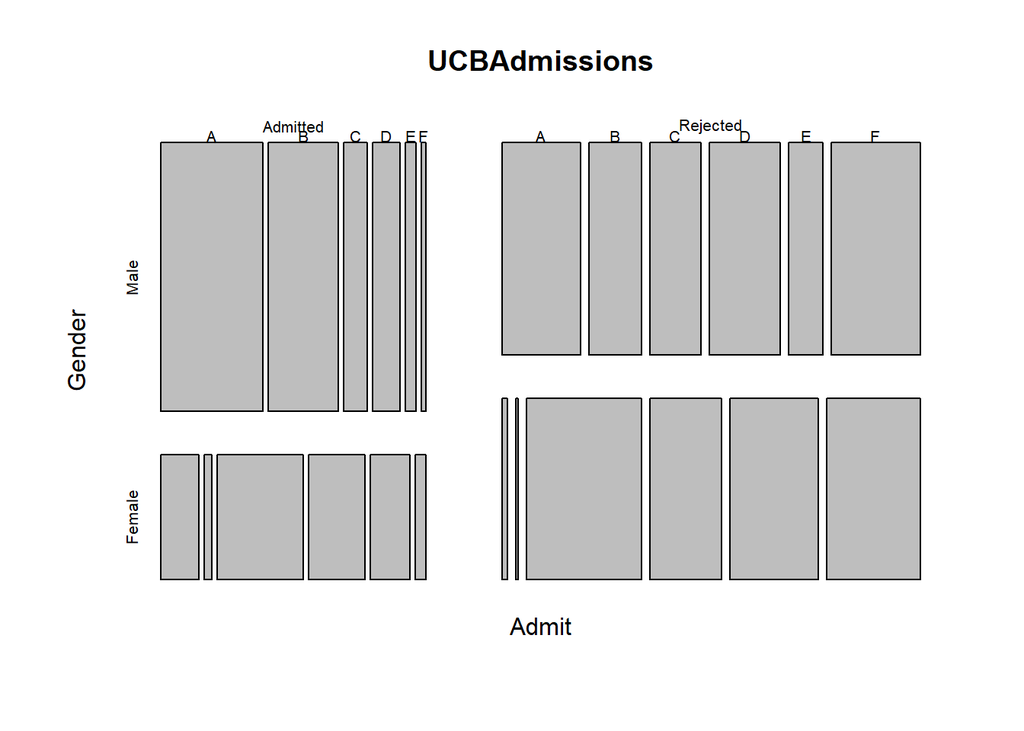

```r
plot(UCBAdmissions)
```

Al aplicar la función, se puede observar cuatro graficas, donde en las cuatro se tienen seis barras. Estos graficos estan relacionados con el data set y estan clasificados por generos y por estado de admision. Las seis barras representan a los departamentos.